# Project 2: Data Mining, Classification, Prediction

SDS322E

# Mining, Classification, Prediction

## Anastasia Nekrashevych, an26692

### Introduction

We are what we eat. When it comes to nutrition, there are a multitude or sources that try to sway people on what is important. In the past, there has been a big emphasis on low calorie foods as an aspect of a healthy lifestyle. Although this has changed over time, calories are still an important measure of foods. In this study I will look at various compositional elements of 8723 foods. The dataset for this study was found on Kaggle and was created by Alexander Antonov. Because there are 77 variables in this dataset, I will concentrate only on amounts of total fat, cholesterol, sodium, vitamin D, magnesium, protein, calcium, iron, folate, and vitamin B12. I will also create a variable called low_cal. The FDA considers foods that are less than or equal to 120 calories per 100 grams as low calorie. All of the foods are measured at 100 grams in this dataset. In this study I hope to get a better understanding about the nutritional content of the foods I consume.

In order to analyze the variables, I will get rid of the measurements inside of the dataset. As a reference, total fat is in g, cholesterol is in mg, sodium is in mg, vitamin D is in IU, magnesium in is mg, protein is in g, calcium is in mg, iron is in mg, folate is in mcg, and vitamin B12 is in mcg.

```r
library(tidyverse)
library(readr)

food <- read_csv("nutrition.csv")

nutrition <- food %>% select(name, calories, total_fat, cholesterol,
    sodium, vitamin_d, magnesium, protein, calcium, irom, folate,
    vitamin_b12)

nutrition$total_fat <- gsub("g", " ", as.character(nutrition$total_fat))
nutrition$cholesterol <- gsub("mg", " ", as.character(nutrition$cholesterol))
nutrition$sodium <- gsub("mg", " ", as.character(nutrition$sodium))
nutrition$vitamin_d <- gsub("IU", " ", as.character(nutrition$vitamin_d))
nutrition$magnesium <- gsub("mg", " ", as.character(nutrition$magnesium))
nutrition$protein <- gsub("g", " ", as.character(nutrition$protein))
nutrition$calcium <- gsub("mg", " ", as.character(nutrition$calcium))
nutrition$irom <- gsub("mg", " ", as.character(nutrition$irom))
nutrition$folate <- gsub("mcg", " ", as.character(nutrition$folate))
nutrition$vitamin_b12 <- gsub("mcg", " ", as.character(nutrition$vitamin_b12))

nutrition <- nutrition %>% rename(iron = irom) %>% mutate(total_fat = as.double(total_fat)) %>%
    mutate(cholesterol = as.double(cholesterol)) %>% mutate(sodium = as.double(sodium)) %>%
    mutate(vitamin_d = as.double(vitamin_d)) %>% mutate(magnesium = as.double(magnesium)) %>%
    mutate(protein = as.double(protein)) %>% mutate(calcium = as.double(calcium)) %>%
    mutate(iron = as.double(iron)) %>% mutate(folate = as.double(folate)) %>%
    mutate(vitamin_b12 = as.double(vitamin_b12))

nutrition$low_cal <- ifelse(nutrition$calories <= 120, 1, 0)

nutrition <- nutrition %>% select(-calories)

nutrition <- nutrition %>% na.omit()
```

### Cluster Analysis

```r
library(cluster)
library(ggplot2)
library(GGally)
clust_dat <- nutrition %>% dplyr::select(-name, -low_cal)
clust_dat
```

```
## # A tibble: 8,722 x 10
##    total_fat cholesterol sodium vitamin_d magnesium protein calcium  iron folate
##        <dbl>       <dbl>  <dbl>     <dbl>     <dbl>   <dbl>   <dbl> <dbl>  <dbl>
##  1       0.1           0      9         0         3    0.26       2  0.47      0
##  2      72             0      0         0       121    9.17      70  2.53     22
##  3       0.2           0      2         0        14    0.98       9  0.23     22
##  4       2.4           0     12         0       184   13.3      180  7.63      0
##  5       2             1     46         0         8    1.1       54  0.14      4
##  6       0.3           0     30         0        15    1.92      22  0.42     57
##  7       0.7           0      3         0        45    4.98     107  2.25    126
##  8      23            73     59         2        21   16.6       16  1.55     18
##  9      24            72    842        18        20   19.8      388  0.33     62
## 10      18             0    490         0        23   23         95  2       102
## # … with 8,712 more rows, and 1 more variable: vitamin_b12 <dbl>
```

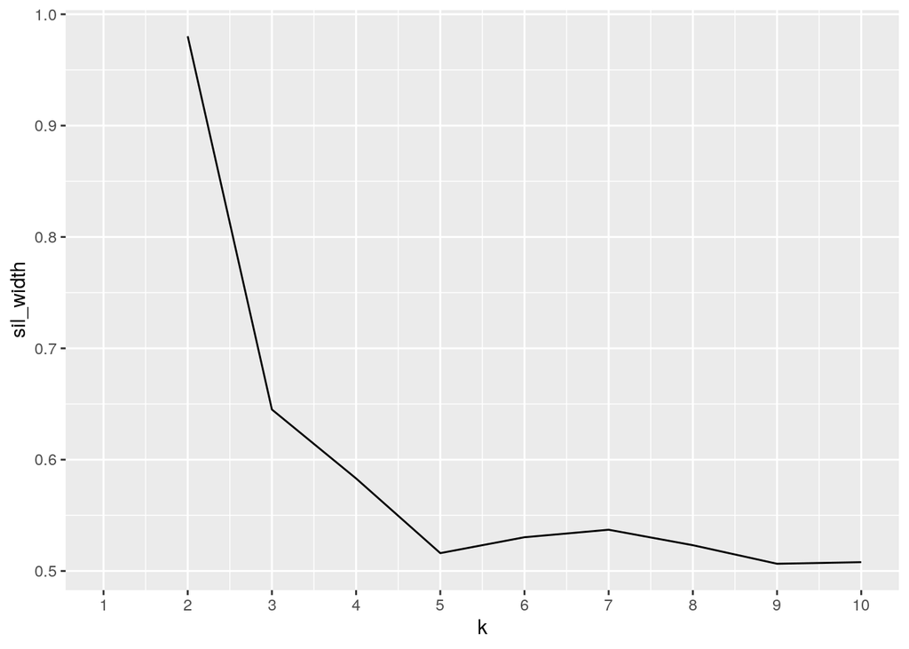

```r
sil_width <- vector()  #empty vector to hold mean sil width
for (i in 2:10) {
    kms <- kmeans(clust_dat, centers = i)  #compute k-means solution
    sil <- silhouette(kms$cluster, dist(clust_dat))  #get sil widths
    sil_width[i] <- mean(sil[, 3])  #take averages (higher is better)
}
ggplot() + geom_line(aes(x = 1:10, y = sil_width)) + scale_x_continuous(name = "k",
    breaks = 1:10)
```

```r
# 2 clusters is best

# running pam
set.seed(322)  #just makes our output match
pam1 <- clust_dat %>% pam(k = 2)
pam1
```

```
## Medoids:
##        ID total_fat cholesterol sodium vitamin_d magnesium protein calcium iron
## [1,] 7805       5.2          53     57         0        24   22.93      25 1.64
## [2,] 2200       6.4          21    564         0        28    9.84      94 1.56
##      folate vitamin_b12
## [1,]     13        1.13
## [2,]     48        0.33
## Clustering vector:
##   [1] 1 1 1 1 1 1 1 1 2 2 2 2 1 1 1 1 2 1 1 2 1 1 1 1 2 1 1 1 1 1 1 1 2 1 2 1 1
##  [38] 1 1 1 2 2 1 2 1 1 1 1 1 1 1 1 1 1 1 1 1 1 2 1 1 2 1 2 2 2 1 1 1 1 2 2 1 1
##  [75] 1 2 2 1 1 1 1 1 2 2 2 1 1 2 1 2 2 2 1 2 1 1 2 1 2 2
##  [ reached getOption("max.print") -- omitted 8622 entries ]
## Objective function:
##    build     swap
## 255.0912 249.5688
##
## Available components:
##  [1] "medoids"    "id.med"     "clustering" "objective"  "isolation"
##  [6] "clusinfo"   "silinfo"    "diss"       "call"       "data"
```

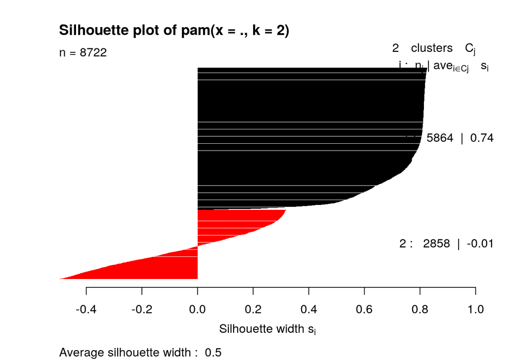

```r
plot(silhouette(pam1, which = 2), col = 1:2, border = NA)
```

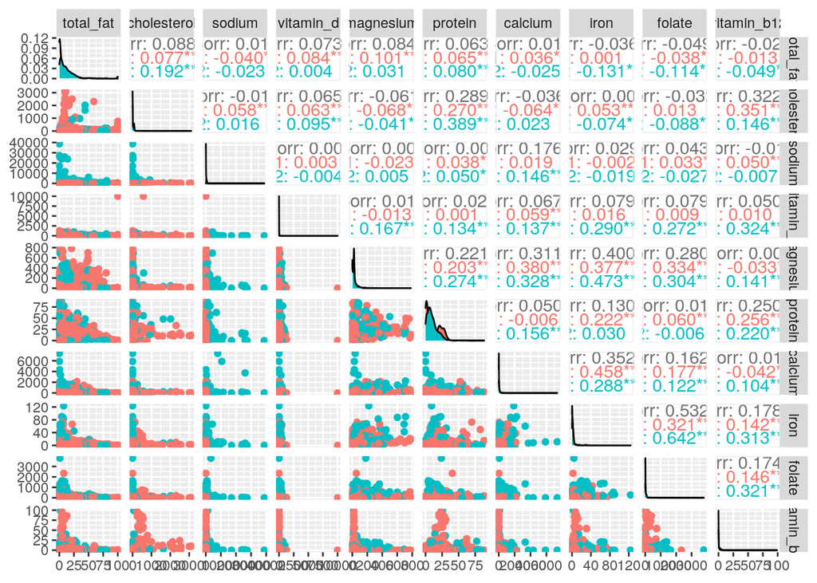

```r
# visualize numeric variables
nutrition %>% mutate(cluster = as.factor(pam1$clustering)) %>%
    ggpairs(columns = 2:11, aes(color = cluster))
```

I first ran a kmeans and through this saw that 2 clusters would work best. After doing the cluster analysis, I got a weak structure. When looking at the gg pairwise graph, I saw that sodium was highly separated. Additionally, iron and folate seemed separated between the two clusters. Vitamin D seemed to have one group have a few food items on the far end and the rest clustered together with the other group. I was surprised with these results! I expected there to be more clusters within the foods depending on these variables. For instance, I expected fruits, cheese, and meat to have distinct clusters. This did not seem to be the case, at least not distinctly and with strong goodness-of-fit.

### Dimensionality Reduction with PCA

```r
# PCA code here
nutrition_nums <- nutrition %>% select(-name, -low_cal) %>% select_if(is.numeric) %>%
    scale

nutrition_pca <- princomp(nutrition_nums)
names(nutrition_pca)
```

```
## [1] "sdev"     "loadings" "center"   "scale"    "n.obs"    "scores"   "call"
```

```r
eigval <- nutrition_pca$sdev^2  #square to convert SDs to eigenvalues
varprop = round(eigval/sum(eigval), 2)  #proportion of var explained by each PC
varprop
```

```
##  Comp.1  Comp.2  Comp.3  Comp.4  Comp.5  Comp.6  Comp.7  Comp.8  Comp.9 Comp.10
##    0.22    0.15    0.11    0.10    0.10    0.08    0.07    0.06    0.05    0.04
```

```r
round(cumsum(eigval)/sum(eigval), 2)
```

```
##  Comp.1  Comp.2  Comp.3  Comp.4  Comp.5  Comp.6  Comp.7  Comp.8  Comp.9 Comp.10
##    0.22    0.37    0.48    0.59    0.69    0.77    0.84    0.91    0.96    1.00
```

```r
eigval
```

```
##    Comp.1    Comp.2    Comp.3    Comp.4    Comp.5    Comp.6    Comp.7    Comp.8
## 2.1650123 1.5382438 1.1239055 1.0319948 1.0181776 0.8410314 0.7248890 0.6182722
##    Comp.9   Comp.10
## 0.5246776 0.4126492
```

```r
# keep 6 PCs

summary(nutrition_pca, loadings = T)  #get PCA summary
```

```
## Importance of components:
##                           Comp.1    Comp.2    Comp.3    Comp.4    Comp.5
## Standard deviation     1.4713981 1.2402596 1.0601441 1.0158714 1.0090479
## Proportion of Variance 0.2165261 0.1538420 0.1124034 0.1032113 0.1018294
## Cumulative Proportion  0.2165261 0.3703681 0.4827715 0.5859828 0.6878123
##                            Comp.6     Comp.7     Comp.8     Comp.9    Comp.10
## Standard deviation     0.91707767 0.85140412 0.78630285 0.72434630 0.64237780
## Proportion of Variance 0.08411279 0.07249721 0.06183431 0.05247377 0.04126966
## Cumulative Proportion  0.77192506 0.84442227 0.90625657 0.95873034 1.00000000
##
## Loadings:
##             Comp.1 Comp.2 Comp.3 Comp.4 Comp.5 Comp.6 Comp.7 Comp.8 Comp.9
## total_fat           0.135  0.671  0.370         0.593         0.126  0.128
## cholesterol         0.622        -0.126                0.298 -0.673 -0.209
## sodium             -0.120  0.368 -0.807         0.180 -0.367        -0.118
## vitamin_d    0.118         0.212         0.845 -0.417 -0.178
## magnesium    0.446 -0.152  0.186  0.300 -0.296 -0.168 -0.187        -0.708
## protein      0.243  0.465  0.156        -0.364 -0.352 -0.437         0.476
## calcium      0.379 -0.225  0.299 -0.224        -0.286  0.664  0.124  0.206
## iron         0.550 -0.126 -0.172                0.101        -0.130  0.256
## folate       0.457 -0.148 -0.327         0.208  0.393 -0.220 -0.216  0.159
## vitamin_b12  0.240  0.496 -0.286 -0.196         0.207  0.152  0.663 -0.250
##             Comp.10
## total_fat
## cholesterol
## sodium
## vitamin_d
## magnesium
## protein     -0.118
## calcium     -0.284
## iron         0.743
## folate      -0.585
## vitamin_b12
```

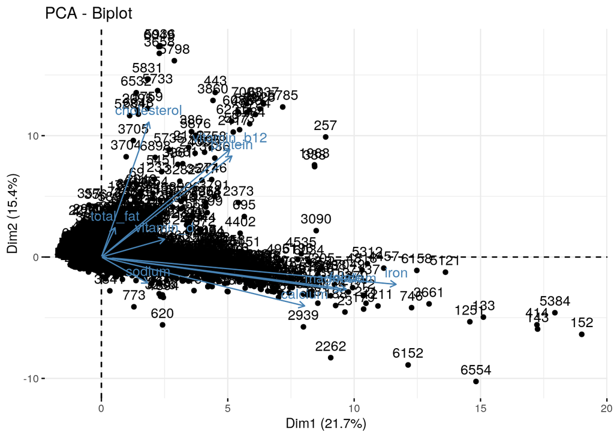

```r
library(factoextra)
fviz_pca_biplot(nutrition_pca)
```

I decided to keep 6 clusters after running the PCA. When looking at the clusters I saw much clearer distinctions than I saw in the clustering section above. PC1 seemed to show healthy foods that are high in vitamins and minerals. These foods seem like generally healthy foods. PC2 seemed to show foods that are high in fat, cholesterol, protein, and vitamin B12. PC2 foods are most likely meats. PC3 showed foods high in everything other than iron, folate, and vitamin B12. PC4 foods were high in fat and magnesium. These are most likely fatty, non-meat foods such as pumpkin seeds, legumes, and nuts. PC5 foods were high in vitamin D and folate, but low in magnesium and protein. Lastly, PC6 showed foods high in fat, sodium, iron, folate, and vitamin B12. The biplot showed that foods high in cholesterol, protein, vitamin B12, and fat grouped closer together than those hgih in iron, calcium, sodium, and magensium.

### Linear Classifier

```r
# logistic classifier
class_dat <- nutrition %>% select(low_cal, total_fat:vitamin_b12)
glimpse(class_dat)
```

```
## Rows: 8,722
## Columns: 11
## $ low_cal     <dbl> 0, 0, 1, 0, 0, 1, 1, 0, 0, 0, 1, 0, 1, 0, 0, 0, 0, 1, 0, …
## $ total_fat   <dbl> 0.1, 72.0, 0.2, 2.4, 2.0, 0.3, 0.7, 23.0, 24.0, 18.0, 0.0…
## $ cholesterol <dbl> 0, 0, 0, 0, 1, 0, 0, 73, 72, 0, 0, 0, 0, 78, 84, 70, 0, 0…
## $ sodium      <dbl> 9, 0, 2, 12, 46, 30, 3, 59, 842, 490, 781, 298, 5, 253, 6…
## $ vitamin_d   <dbl> 0, 0, 0, 0, 0, 0, 0, 2, 18, 0, 0, 0, 0, 0, 8, 0, 0, 0, 0,…
## $ magnesium   <dbl> 3, 121, 14, 184, 8, 15, 45, 21, 20, 23, 0, 0, 3, 36, 5, 2…
## $ protein     <dbl> 0.26, 9.17, 0.98, 13.30, 1.10, 1.92, 4.98, 16.56, 19.80, …
## $ calcium     <dbl> 2, 70, 9, 180, 54, 22, 107, 16, 388, 95, 0, 190, 17, 27, …
## $ iron        <dbl> 0.47, 2.53, 0.23, 7.63, 0.14, 0.42, 2.25, 1.55, 0.33, 2.0…
## $ folate      <dbl> 0, 22, 22, 0, 4, 57, 126, 18, 62, 102, 0, 0, 7, 87, 86, 7…
## $ vitamin_b12 <dbl> 0.00, 0.00, 0.00, 0.00, 0.13, 0.00, 0.00, 2.31, 1.30, 4.2…
```

```r
fit <- glm(low_cal ~ ., data = class_dat, family = "binomial")
probs <- predict(fit, type = "response")
class_diag(probs, class_dat$low_cal, positive = 1)
```

```
##            acc   sens   spec    ppv     f1     ba    auc
## Metrics 0.9024 0.8714 0.9173 0.8344 0.8525 0.8943 0.9554
```

```r
# confusion matrix
table(truth = class_dat$low_cal, predictions = probs > 0.5)
```

```
##      predictions
## truth FALSE TRUE
##     0  5412  488
##     1   363 2459
```

```r
# cross-validation of linear classifier here
set.seed(322)
k = 10

data <- sample_frac(nutrition)  #randomly order rows
folds <- rep(1:k, length.out = nrow(data))  #create folds

diags <- NULL

i = 1
for (i in 1:k) {
    # create training and test sets
    train <- data[folds != i, ]
    test <- data[folds == i, ]
    truth <- test$low_cal

    # train model
    fit <- glm(low_cal ~ total_fat + cholesterol + sodium + vitamin_d +
        magnesium + protein + calcium + iron + folate + vitamin_b12,
        data = train, family = "binomial")

    # test model
    probs <- predict(fit, newdata = test, type = "response")

    # get performance metrics for each fold
    diags <- rbind(diags, class_diag(probs, truth, positive = 1))
}

# average performance metrics across all folds
summarize_all(diags, mean)
```

```
##      acc    sens    spec     ppv      f1      ba     auc
## 1 0.9021 0.87101 0.91708 0.83424 0.85205 0.89406 0.95495
```

I ran a logistic regression as a linear classifier. This gave me an AUC of 0.955, which is great. When I ran a confusion matrix on this I got 2459 true positives, 5412 true negatives, 488 false positives, and 363 false negatives. After running a 10-fold cross-validation the AUC barely went down to 0.95495. This model does not show signs of over-fitting. This model has good out-of-sample performance!

### Non-Parametric Classifier

```r
library(caret)

fit <- knn3(low_cal ~ ., data = class_dat)
probs <- predict(fit, newdata = class_dat)[, 2]  #we choose the second column since that's the probability of 'True'
class_diag(probs, class_dat$low_cal, positive = 1)
```

```
##            acc   sens   spec  ppv     f1     ba    auc
## Metrics 0.9117 0.8685 0.9324 0.86 0.8642 0.9005 0.9743
```

```r
table(truth = class_dat$low_cal, predictions = probs > 0.5)
```

```
##      predictions
## truth FALSE TRUE
##     0  5501  399
##     1   371 2451
```

```r
# cross-validation of np classifier here
set.seed(322)
k = 10

data <- sample_frac(nutrition)  #randomly order rows
folds <- rep(1:k, length.out = nrow(data))  #create folds

diags <- NULL

i = 1
for (i in 1:k) {
    # create training and test sets
    train <- data[folds != i, ]
    test <- data[folds == i, ]
    truth <- test$low_cal

    # train model
    fit <- knn3(low_cal ~ total_fat + cholesterol + sodium +
        vitamin_d + magnesium + protein + calcium + iron + folate +
        vitamin_b12, data = train)

    # test model
    probs <- predict(fit, newdata = test)[, 2]

    # get performance metrics for each fold
    diags <- rbind(diags, class_diag(probs, truth, positive = 1))
}

# average performance metrics across all folds
summarize_all(diags, mean)
```

```
##       acc    sens   spec    ppv      f1     ba     auc
## 1 0.87068 0.81349 0.8981 0.7927 0.80259 0.8558 0.93155
```

I ran a k-nearest-neighbors fit as a non-parametric classifier. This gave me an AUC of 0.9743, which is great. Additionally, I ran a confusion matrix. This showed 2451 true positives, 5501 true negatives, 399 false positives, and 371 false negatives. Afterwards, I ran a 10-fold cross-validation of the non-parametric classifier. This gave me an AUC of 0.93155. Although this did decrease the original AUC, it remained great and did not show signs of over-fitting. This, together with the linear classifier shows that the data follows both models well and fits well for out-of-sample predictions. This shows that low calorie foods have properties regarding their composition that can be easily determined through modeling. This is not particularly surprising.

### Regression/Numeric Prediction

```r
# regression model code here
fit <- lm(total_fat ~ cholesterol + sodium + vitamin_d + magnesium +
    protein + calcium + iron + folate + vitamin_b12, data = nutrition)

yhat <- predict(fit)

mean((nutrition$total_fat - yhat)^2)
```

```
## [1] 242.0051
```

```r
# cross-validation of regression model here
set.seed(1234)
k = 10  #choose number of folds
data <- nutrition %>% sample_frac()  #randomly order rows
folds <- cut(seq(1:nrow(nutrition)), breaks = k, labels = F)  #create folds
diags <- NULL
for (i in 1:k) {
    train <- data[folds != i, ]
    test <- data[folds == i, ]
    ## Fit linear regression model to training set
    fit <- knnreg(total_fat ~ cholesterol + sodium + vitamin_d +
        magnesium + protein + calcium + iron + folate + vitamin_b12,
        data = train)
    ## Get predictions/y-hats on test set (fold i)
    yhat <- predict(fit, newdata = test)
    ## Compute prediction error (MSE) for fold i
    diags <- mean((test$total_fat - yhat)^2)
}
mean(diags)  ## get average MSE across all folds (much higher error)!
```

```
## [1] 111.278
```

### Python

```r
library(reticulate)

good = "All food is good"
cat(c(good, py$moderate))
```

```
## All food is good
```

```python
# python code here

moderate = "in moderation."
print(r.good, moderate)
```

```
## All food is good in moderation.
```

### Concluding Remarks

This study showed some aspects of nutrition based on a variety of variables indicating a food’s composition. Low calorie foods were shown to have qualities that separated them from other foods. High fat content foods did not seem to have qualities that separated them significantly between each other. An interesting future study would be to place food names into general groups such as “dairy products” and see how the groupings differed in nutritional content.